[figure not shown]

[figure not shown]

[figure not shown]

# Problema 1

## Teorema del Límite Central

El Teorema del Límite Central es uno de los más importantes en la inferencia estadística y habla sobre la convergencia de los estimadores como la proporción muestral a la distribución normal. Algunos autores afirman que esta aproximación es bastante buena a partir del umbral n>30.

A continuación se describen los siguientes pasos para su verificación:

### a. Simulación

**a.** Realice una simulación en la cual genere una población de N=1000 (Lote), donde el porcentaje de individuos (supongamos plantas) enfermas sea del 50%.

```r
poblacion1 <- sample(c(rep(1, 1000*0.5), rep(0, 1000*0.5)))
poblacion1
```

[output not shown]

```r
summary(poblacion1)
```

```
   Min. 1st Qu.  Median    Mean 3rd Qu.    Max.
    0.0     0.0     0.5     0.5     1.0     1.0
```

### b. Muestras

**b.** Genere una función que permita: - Obtener una muestra aleatoria de la población y

```r
#El número aleatorio se usa para obtener una muestra de tamaño aleatorio.
numeroAleatorio1 <- runif(1, 100, 1000);
numeroAleatorio1
```

```
[1] 868.0445
```

```r
muestraAleatoria1 <- sample(poblacion1, numeroAleatorio1, replace = FALSE)
muestraAleatoria1
```

```
  [1] 0 0 0 1 0 1 0 1 1 1 0 0 0 1 1 0 0 1 1 0 0 1 1 1 1 1 1 1 0 1 1 1 1 0 1 1 1
 [38] 1 1 0 1 1 1 0 1 0 1 0 1 0 0 1 1 0 0 1 1 0 0 1 1 0 0 0 0 1 1 1 1 1 1 1 0 1
 [75] 0 0 0 0 0 0 1 0 0 0 1 0 0 1 1 0 0 1 0 0 0 0 0 0 0 0 1 1 0 0 0 1 1 0 0 0 0
[112] 0 1 1 1 1 0 1 1 0 0 0 0 0 1 0 1 0 1 0 0 1 0 1 0 1 0 0 1 1 1 0 0 1 0 1 1 0
[149] 1 1 1 1 1 1 0 1 1 1 0 0 1 0 0 1 1 0 1 1 0 0 0 0 0 1 1 1 0 0 1 0 0 1 0 1 1
[186] 0 1 1 1 1 0 1 0 0 0 0 0 0 1 0 1 1 0 1 0 1 1 1 0 0 0 1 0 0 0 0 1 1 0 0 1 1
[223] 0 1 0 0 0 0 1 0 0 0 1 1 0 1 1 1 1 1 0 1 1 1 0 1 1 1 0 0 0 0 1 1 1 1 0 1 0
[260] 1 0 1 0 1 1 1 0 0 0 0 1 1 0 1 0 0 1 1 0 1 1 1 0 1 0 0 0 0 1 1 1 1 1 0 0 1
[297] 0 0 1 0 0 1 1 1 0 0 1 1 1 0 1 1 1 1 1 0 1 0 1 0 0 0 0 1 1 1 0 0 0 0 1 0 1
[334] 1 0 0 0 1 1 1 0 1 0 1 1 0 1 0 1 1 0 1 0 1 0 0 0 0 1 0 1 1 1 0 1 0 0 0 1 1
[371] 1 0 1 0 0 0 1 0 1 1 1 1 0 0 0 1 0 0 0 1 0 0 1 0 0 0 1 1 0 1 0 0 0 0 0 1 1
[408] 1 0 0 1 1 0 1 1 1 1 0 0 1 1 1 0 1 0 0 1 1 0 1 0 1 1 1 1 1 1 1 0 1 0 0 0 1
[445] 0 1 1 0 0 0 1 1 1 0 1 1 1 1 0 0 0 0 0 0 0 1 1 0 1 1 1 0 0 1 0 0 1 0 1 0 0
[482] 1 0 1 0 0 0 0 1 1 0 1 1 1 0 0 1 0 0 0 0 0 0 0 1 1 0 0 0 1 1 1 1 1 1 0 1 0
[519] 1 1 0 0 1 0 0 0 0 1 0 1 0 0 1 1 0 0 0 1 0 0 1 0 1 1 0 1 1 1 1 1 0 1 1 1 0
[556] 1 0 1 0 0 1 1 0 1 1 1 0 1 1 0 0 1 0 0 0 1 0 0 1 1 1 0 0 0 1 1 0 0 1 1 1 0
[593] 0 0 1 1 1 0 0 1 1 0 1 0 1 0 0 1 0 1 1 1 0 0 0 0 1 1 0 0 0 1 1 1 1 1 1 1 1
[630] 0 0 0 1 1 0 1 0 0 1 0 1 1 0 0 0 1 0 1 0 1 1 0 1 1 0 1 1 1 0 1 0 1 1 1 1 1
[667] 1 0 0 1 0 1 0 1 1 0 0 0 1 1 0 0 1 0 0 0 1 0 0 0 0 0 1 0 0 1 1 1 1 1 1 1 0
[704] 1 0 0 1 0 0 0 1 0 0 0 0 1 1 1 1 0 1 0 0 1 1 0 0 1 1 1 1 0 0 0 0 1 0 0 0 1
[741] 1 0 1 0 1 0 1 1 1 1 0 0 1 0 0 0 1 0 0 0 0 1 1 1 0 0 1 0 1 0 0 1 0 0 1 1 1
[778] 0 0 1 1 0 0 0 1 0 1 1 0 0 1 1 1 1 1 0 1 1 1 1 0 0 0 1 1 0 0 1 0 0 1 0 1 0
[815] 0 0 1 0 1 0 1 1 0 0 0 0 0 1 0 0 0 0 1 1 0 0 1 0 1 0 0 1 1 1 1 0 1 0 0 1 1
[852] 1 0 1 0 0 1 1 1 0 0 1 0 1 0 0 0 1
```

- Calcule el estimador de la proporción muestral pˆ para un tamaño de muestra dado n.

```r
pEstimadorMuestraAleatoria1 <- sum(muestraAleatoria1 == 1) / length(muestraAleatoria1)
pEstimadorMuestraAleatoria1
```

```
[1] 0.5
```

### c. 500 veces (b)

**c.** Repita el escenario anterior (b) n=500 veces y analice los resultados en cuanto al comportamiento de los 500 resultados del estimador pˆ. ¿Qué tan simétricos o sesgados son los resultados obtenidos? y ¿qué se puede observar en cuanto a la variabilidad?. Realice en su informe un comentario sobre los resultados obtenidos.

```r
tablaEstimadores = data.frame(matrix(nrow = 0, ncol = 2))
colnames(tablaEstimadores) = c("tamaño muestra", "estimadorP");
for(i in 1:500) {
  numeroAleatorio1 <- runif(1, 100, 1000);
  muestraAleatoria1 <- sample(poblacion1, numeroAleatorio1, replace = FALSE)
  pEstimadorMuestraAleatoria1 <- sum(muestraAleatoria1 == 1) / length(muestraAleatoria1)
  row <- c(numeroAleatorio1,pEstimadorMuestraAleatoria1)
  tablaEstimadores[nrow(tablaEstimadores)+1,]  = row
}
print(tablaEstimadores)
```

```
    tamaño muestra estimadorP
1         519.8170  0.4971098
2         527.6023  0.5237192
3         429.7204  0.5174825
4         787.6326  0.4942821
5         997.9352  0.5005015
6         439.9957  0.5216401
7         624.4092  0.5064103
8         408.1778  0.5294118
9         148.0518  0.5000000
10        559.7852  0.4830054
11        446.0908  0.4955157
12        817.1105  0.4895961
13        144.9256  0.5069444
14        710.7796  0.5056338
```

[output cut: 486 more lines]

```r
summary(tablaEstimadores)
```

```
 tamaño muestra    estimadorP
 Min.   :100.1   Min.   :0.4331
 1st Qu.:340.7   1st Qu.:0.4916
 Median :578.0   Median :0.4994
 Mean   :559.2   Mean   :0.4998
 3rd Qu.:781.3   3rd Qu.:0.5079
 Max.   :997.9   Max.   :0.5658
```

```r
desviacionEstandar <- sd(tablaEstimadores$"estimador")
cat("La desviación estandar es de ",desviacionEstandar)
```

```
La desviación estandar es de  0.01745806
```

### d. Repetición (b) y (c) tamaño muestra

**d.** Repita los puntos b y c para tamaños de muestra n=5, 10, 15, 20, 30, 50, 60, 100, 200, 500. Compare los resultados obtenidos para los diferentes tamaños de muestra en cuanto a la normalidad. Utilice pruebas de bondad y ajuste (shapiro wilks :shspiro.test()) y métodos gráficos (grafico de normalidad: qqnorm()). Comente ensu informe los resultados obtenidos

```r
tamanosMuestra = c(5, 10, 15, 20, 30, 50, 60, 100, 200, 500)
tamanosMuestra
```

```
 [1]   5  10  15  20  30  50  60 100 200 500
```

```r
for(tamanoMuestra in tamanosMuestra) {
  cat("\n\nMuestra tamano: " , tamanoMuestra, '\n')
  muestra <- sample(poblacion1, tamanoMuestra, replace = FALSE)
  cat(muestra)
  pEstimadorMuestra <- sum(muestra == 1) / length(muestra)
  cat("\nEstimador de la proporción muestral: ", pEstimadorMuestra)
  print(shapiro.test(muestra))

}
```

```
Muestra tamano:  5
0 1 0 1 0
Estimador de la proporción muestral:  0.4
    Shapiro-Wilk normality test

data:  muestra
W = 0.68403, p-value = 0.00647



Muestra tamano:  10
0 1 0 0 0 0 1 1 0 0
Estimador de la proporción muestral:  0.3
    Shapiro-Wilk normality test

data:  muestra
W = 0.59417, p-value = 4.713e-05



Muestra tamano:  15
0 0 0 1 0 1 0 0 1 1 1 1 0 1 1
Estimador de la proporción muestral:  0.5333333
    Shapiro-Wilk normality test

data:  muestra
W = 0.64341, p-value = 6.562e-05



Muestra tamano:  20
1 0 1 0 0 1 1 0 0 0 1 1 1 1 0 1 1 1 0 0
Estimador de la proporción muestral:  0.55
    Shapiro-Wilk normality test

data:  muestra
W = 0.63748, p-value = 7.387e-06



```

[output cut: 42 more lines]

```
Estimador de la proporción muestral:  0.51
    Shapiro-Wilk normality test

data:  muestra
W = 0.63629, p-value < 2.2e-16



Muestra tamano:  500
0 1 1 0 0 0 1 0 1 1 0 1 1 1 0 0 0 0 1 0 1 1 1 1 0 1 1 0 1 1 0 1 0 1 1 0 0 1 0 0 1 1 1 1 1 0 0 1 1 1 1 0 0 0 1 1 1 0 0 1 0 1 0 1 1 1 0 0 1 0 0 0 1 0 1 1 0 1 1 0 0 0 1 1 0 0 1 1 1 1 1 0 1 1 1 0 1 1 0 1 1 1 1 0 0 1 0 0 0 1 0 1 0 0 1 1 0 1 0 0 1 0 1 1 1 0 0 0 1 0 1 0 0 1 0 0 0 1 1 1 0 0 1 0 0 1 1 0 0 1 …
Estimador de la proporción muestral:  0.514
    Shapiro-Wilk normality test

data:  muestra
W = 0.63626, p-value < 2.2e-16
```

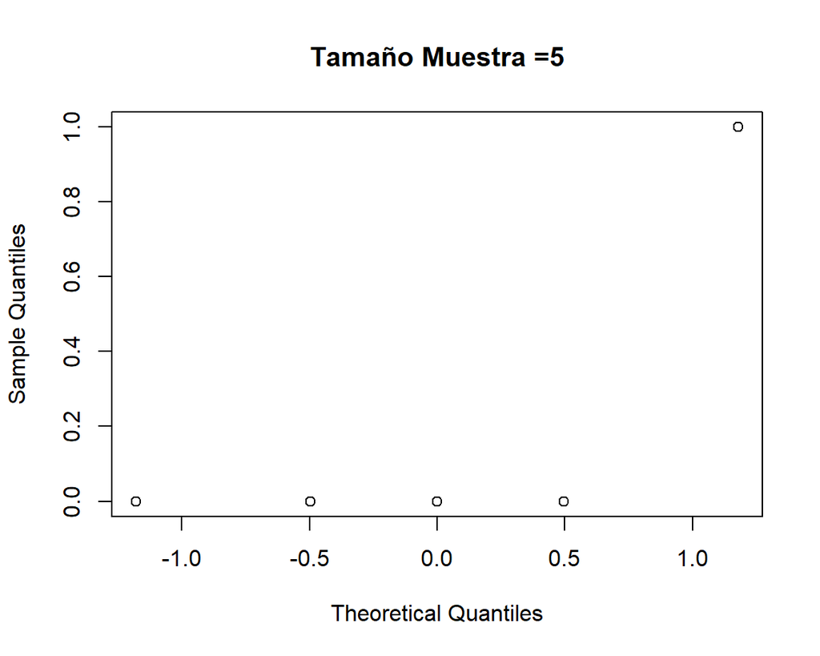

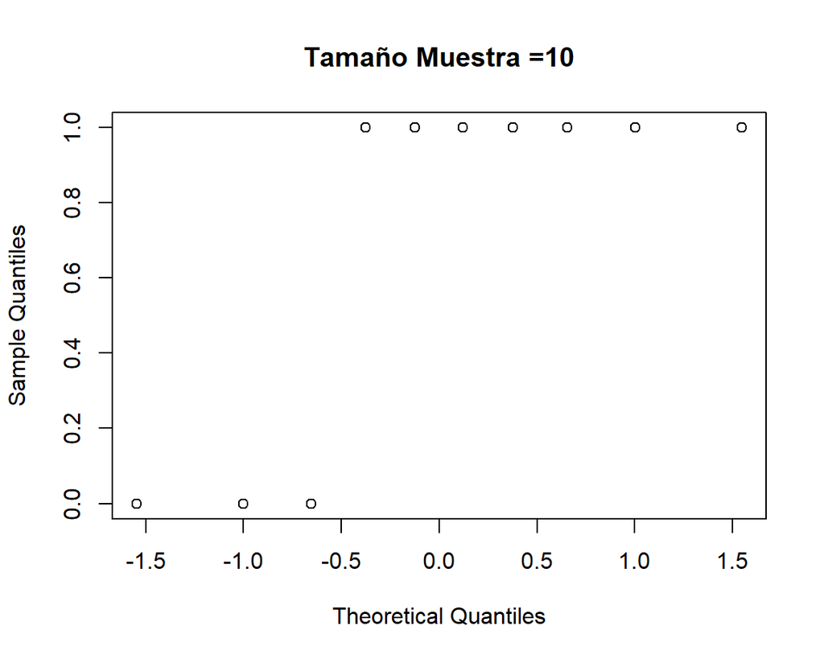

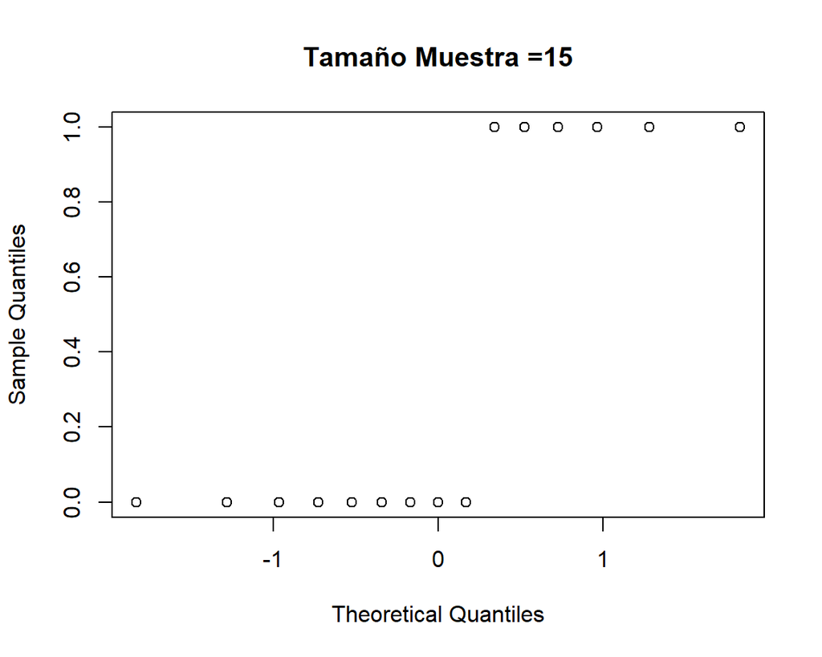

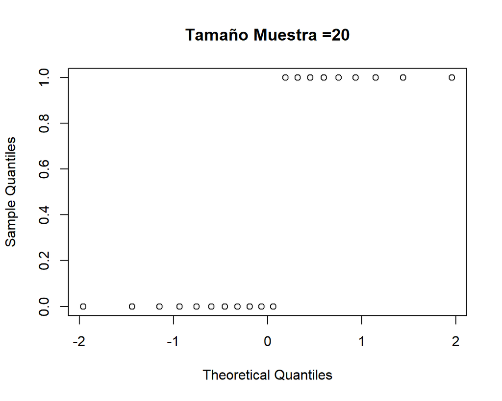

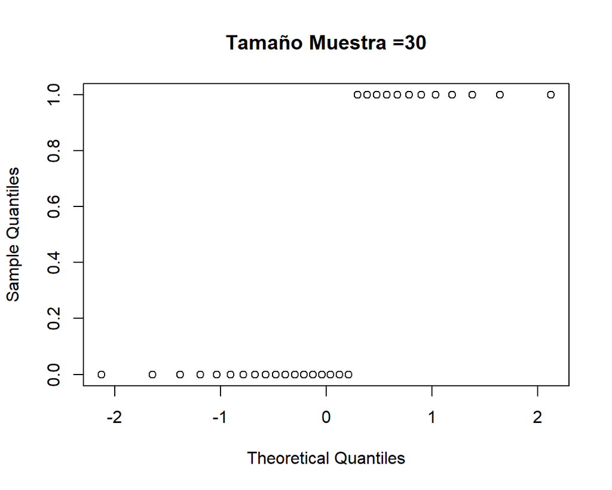

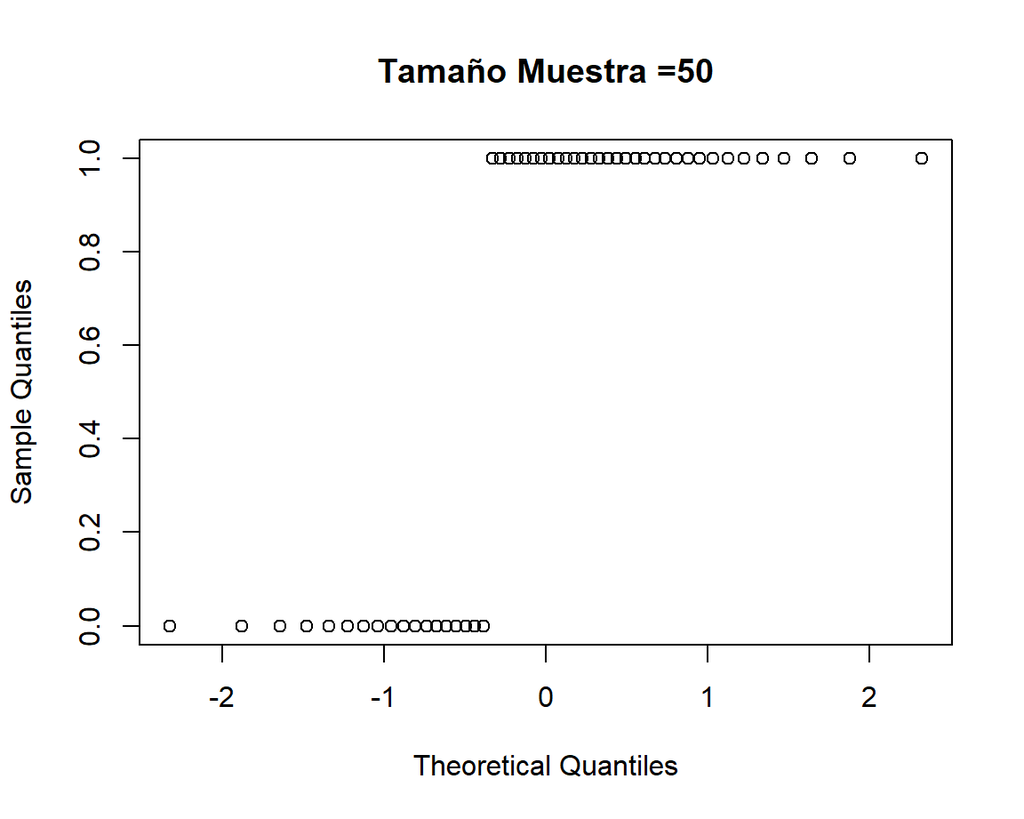

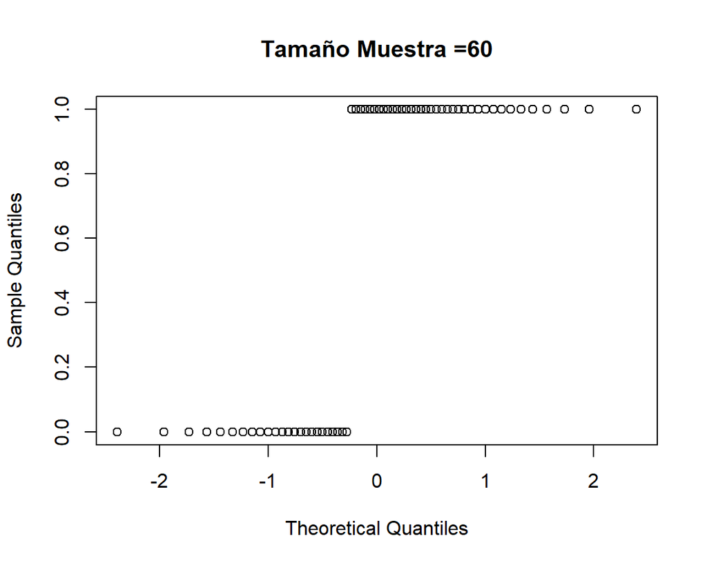

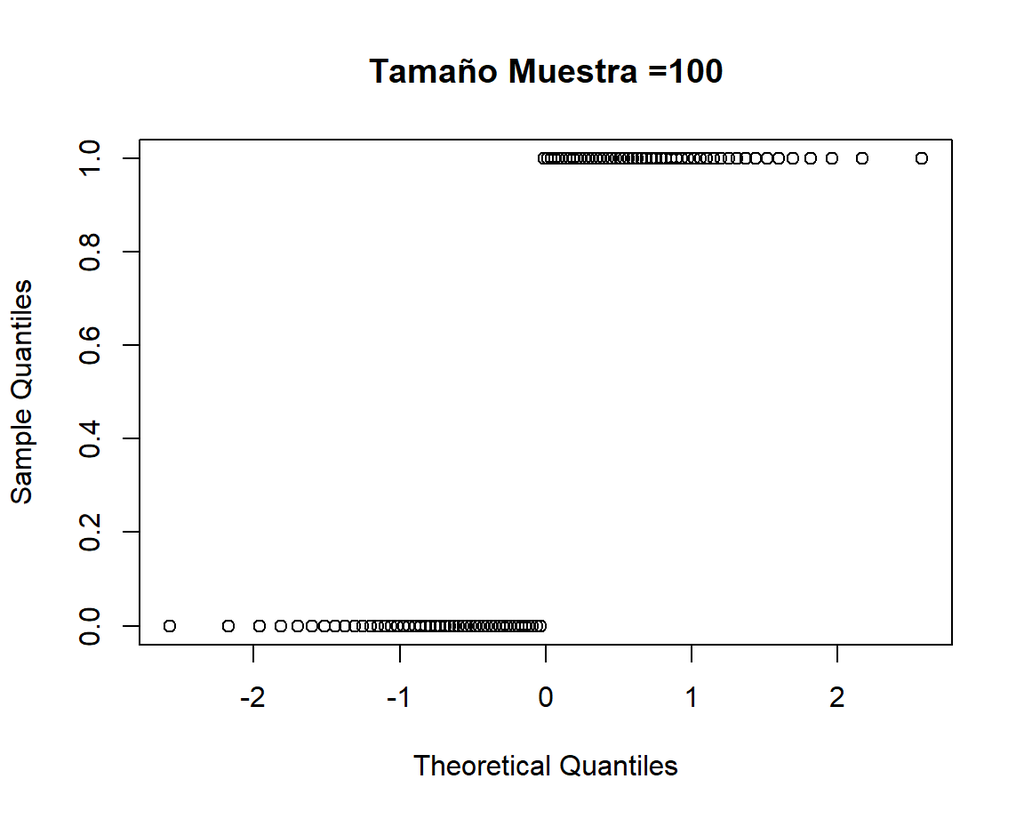

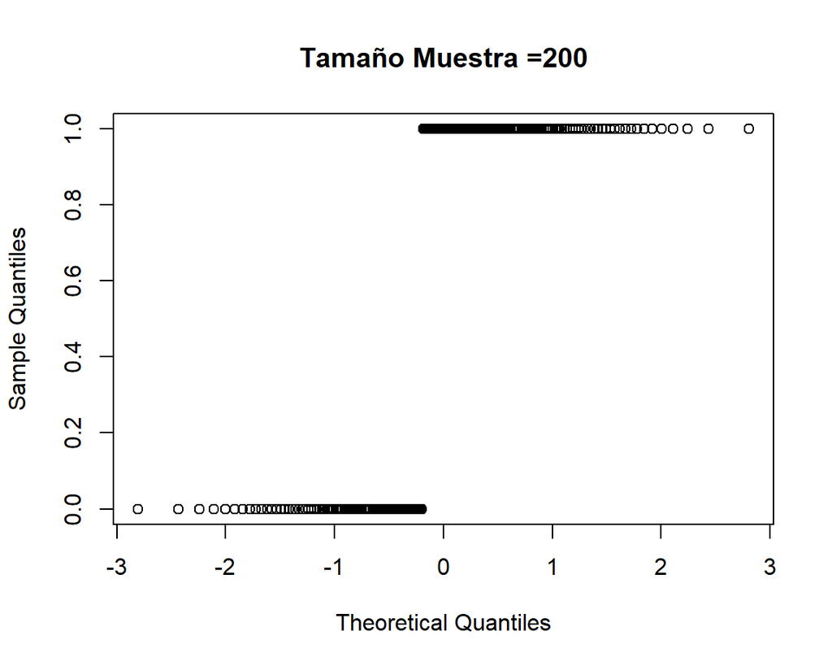

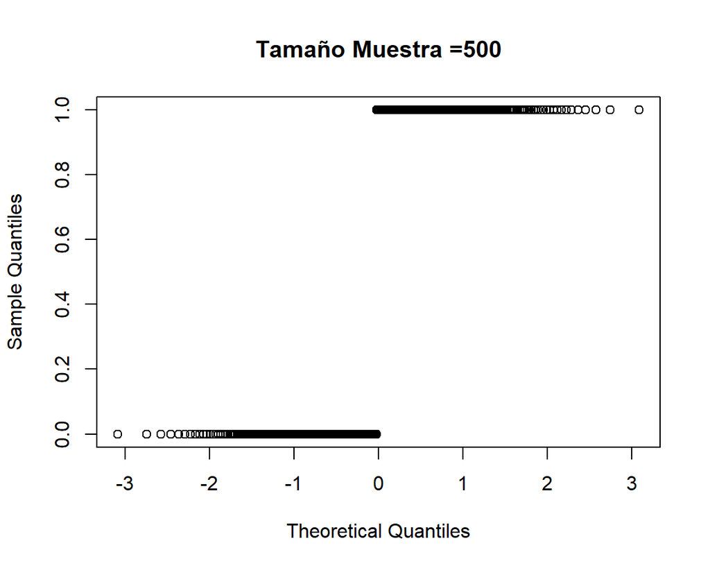

```r
for(tamanoMuestra in tamanosMuestra) {
  muestra <- sample(poblacion1, tamanoMuestra, replace = FALSE)
  qqnorm(muestra, main=paste0("Tamaño Muestra =", tamanoMuestra))
}
```

### e. Simulacion con X% plantas enfermas

**e.** Repita toda la simulación (puntos a – d), pero ahora para lotes con 10% de plantas enfermas y de nuevo para lotes con un 90% de plantas enfermas. Concluya sobre los resultados del ejercicio.

**Lote con 10% de plantas enfermas**

```r
poblacion10PorcientoEnferma <- sample(c(rep(1, 1000*0.1), rep(0, 1000*0.9)))
poblacion10PorcientoEnferma
```

[output not shown]

```r
numeroAleatorio2 <- runif(1, 100, 500);
numeroAleatorio2
```

```
[1] 164.6331
```

```r
muestraAleatoria2 <- sample(poblacion10PorcientoEnferma, numeroAleatorio2, replace = FALSE)
muestraAleatoria2
```

```
  [1] 0 0 0 0 0 1 0 0 1 0 0 0 0 0 0 0 0 0 0 0 0 0 1 0 1 0 0 0 0 0 0 0 0 0 0 0 0
 [38] 0 0 0 0 0 0 0 0 0 0 0 0 0 0 0 0 0 0 1 0 0 0 0 0 0 0 0 0 1 0 0 0 0 0 0 1 0
 [75] 0 0 1 0 0 0 0 0 1 0 0 0 1 0 0 0 0 0 0 0 0 0 0 0 0 0 0 0 0 1 0 0 0 0 0 0 0
[112] 0 0 0 0 1 0 0 0 0 0 0 0 0 0 0 1 0 1 0 0 0 0 1 0 0 0 0 1 0 0 1 0 0 0 0 0 0
[149] 0 0 0 0 0 1 0 0 0 0 0 0 0 0 0 0
```

```r
pEstimadorMuestraAleatoria2 <- sum(muestraAleatoria2 == 1) / length(muestraAleatoria2)
pEstimadorMuestraAleatoria2
```

```
[1] 0.1097561
```

```r
pEstimadorMuestraAleatoria2 <- sum(muestraAleatoria2 == 1) / length(muestraAleatoria2)
pEstimadorMuestraAleatoria2
```

```
[1] 0.1097561
```

```r
tamanosMuestra = c(5, 10, 15, 20, 30, 50, 60, 100, 200, 500)
tamanosMuestra
```

```
 [1]   5  10  15  20  30  50  60 100 200 500
```

```r
for(tamanoMuestra in tamanosMuestra) {
  cat("\n\nMuestra tamano: " , tamanoMuestra, '\n')
  muestraAleatoria3 <- sample(poblacion10PorcientoEnferma, tamanoMuestra, replace = FALSE)
  cat(muestraAleatoria3)
  pEstimadorMuestraAleatoria3 <- sum(muestraAleatoria3 == 1) / length(muestraAleatoria3)
  cat("\nEstimador de la proporción muestral: ", pEstimadorMuestraAleatoria3)
  print(shapiro.test(muestra))
}
```

```
Muestra tamano:  5
0 0 0 1 0
Estimador de la proporción muestral:  0.2
    Shapiro-Wilk normality test

data:  muestra
W = 0.63645, p-value < 2.2e-16



Muestra tamano:  10
0 0 0 0 0 0 0 0 0 0
Estimador de la proporción muestral:  0
    Shapiro-Wilk normality test

data:  muestra
W = 0.63645, p-value < 2.2e-16



Muestra tamano:  15
0 0 0 0 0 0 0 0 0 0 0 1 0 0 0
Estimador de la proporción muestral:  0.06666667
    Shapiro-Wilk normality test

data:  muestra
W = 0.63645, p-value < 2.2e-16



Muestra tamano:  20
0 0 0 0 0 0 0 0 0 0 0 1 0 0 0 0 0 0 0 0
Estimador de la proporción muestral:  0.05
    Shapiro-Wilk normality test

data:  muestra
W = 0.63645, p-value < 2.2e-16



```

[output cut: 42 more lines]

```
Estimador de la proporción muestral:  0.085
    Shapiro-Wilk normality test

data:  muestra
W = 0.63645, p-value < 2.2e-16



Muestra tamano:  500
0 0 0 0 0 0 0 0 0 0 0 0 0 0 0 0 0 0 0 0 0 0 0 0 0 0 0 0 0 0 0 0 0 0 0 0 0 0 0 0 0 0 0 1 0 0 0 1 0 1 0 0 0 0 0 0 0 0 0 0 0 1 0 0 0 0 0 0 0 0 0 0 0 1 0 0 0 1 0 0 0 0 0 0 0 0 0 0 0 0 0 0 0 0 0 0 0 0 0 0 0 0 1 0 0 0 0 0 0 0 0 0 0 0 0 0 0 0 0 0 1 0 0 0 0 0 0 0 0 0 0 0 0 0 0 0 0 0 0 0 0 0 0 0 0 1 1 1 0 1 …
Estimador de la proporción muestral:  0.108
    Shapiro-Wilk normality test

data:  muestra
W = 0.63645, p-value < 2.2e-16
```

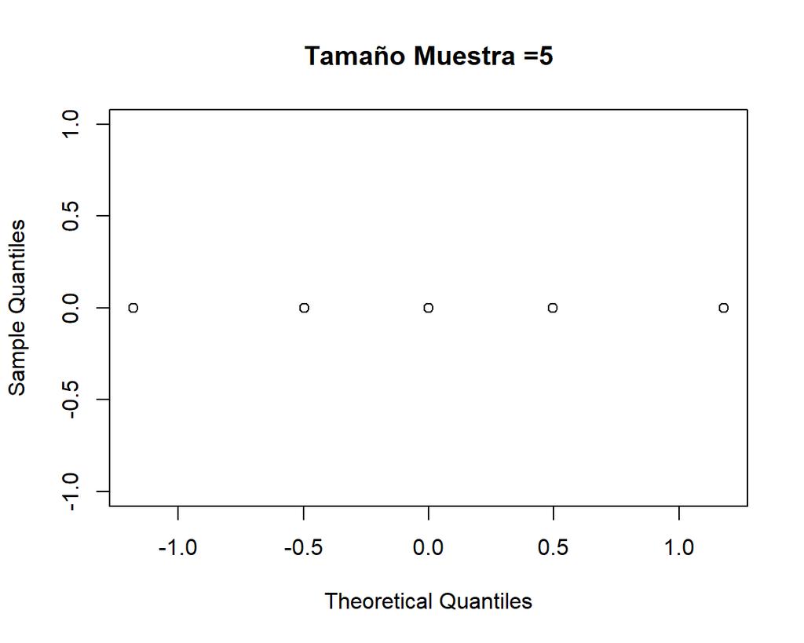

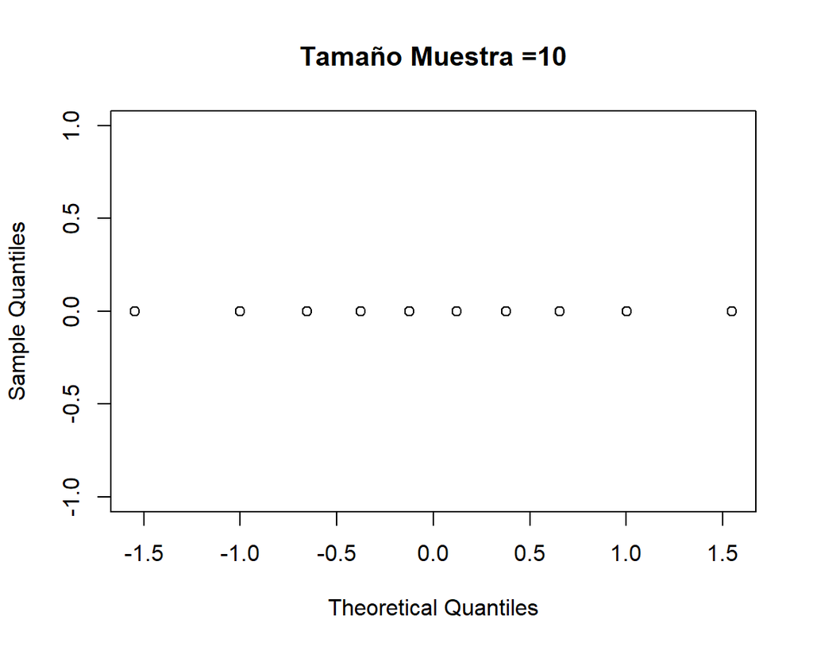

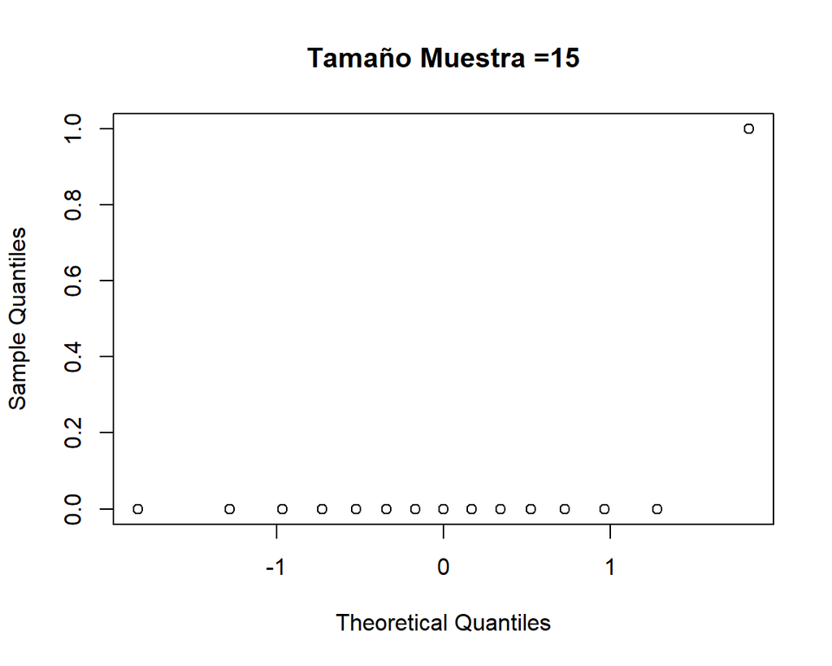

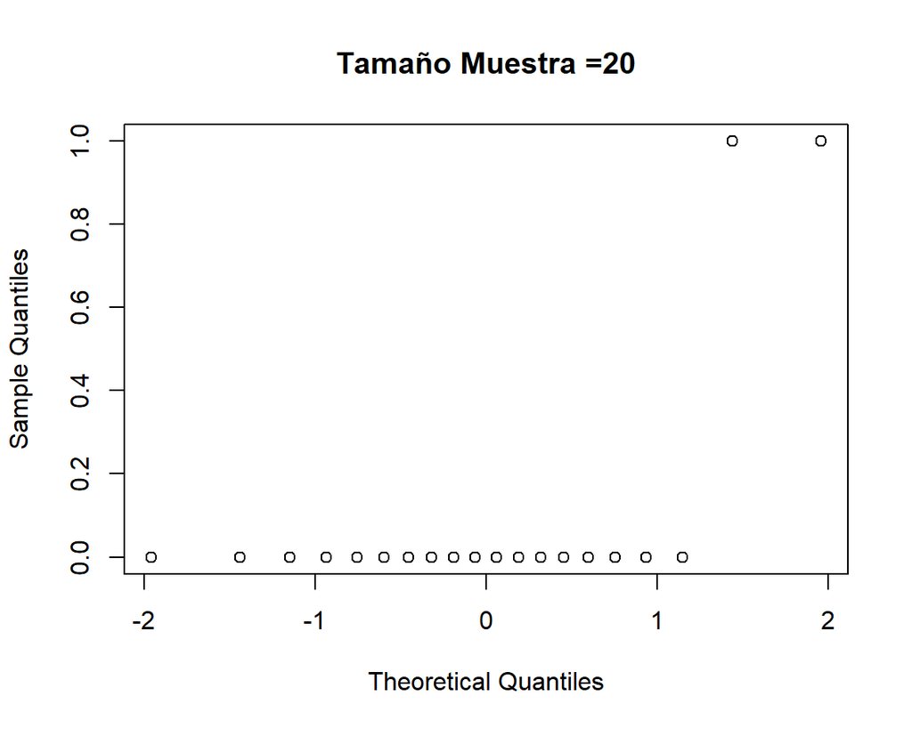

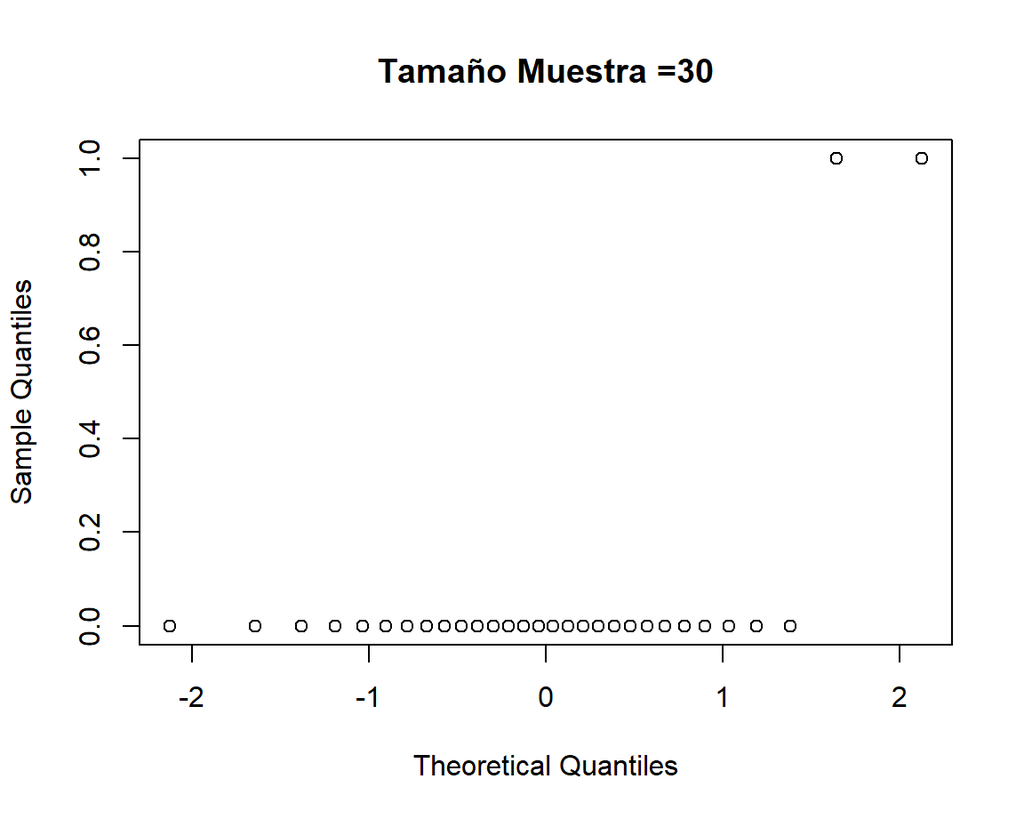

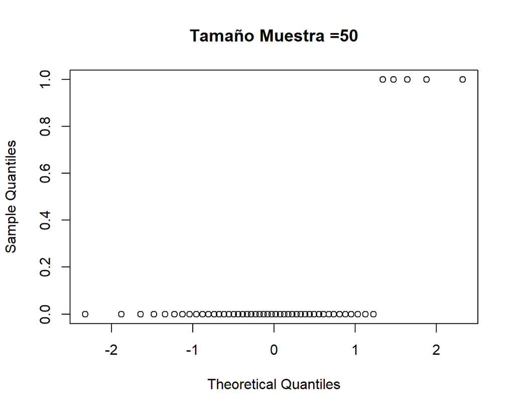

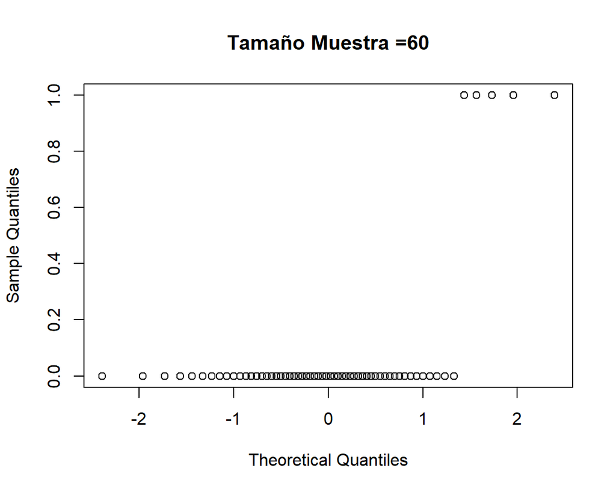

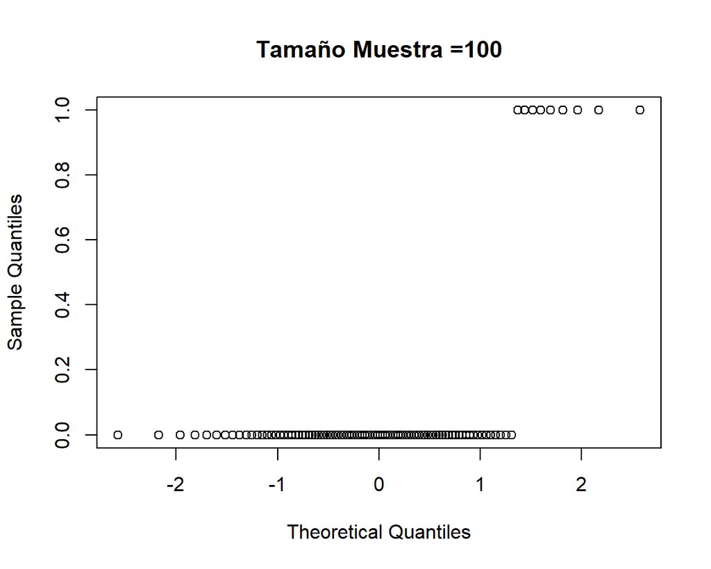

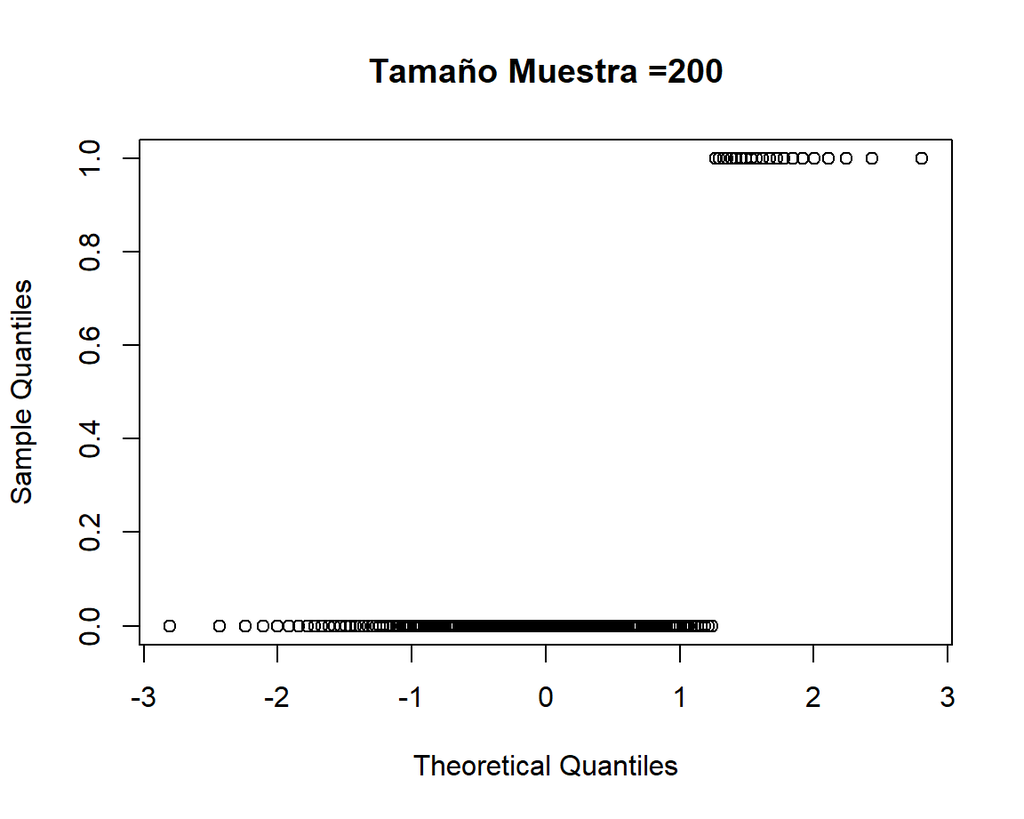

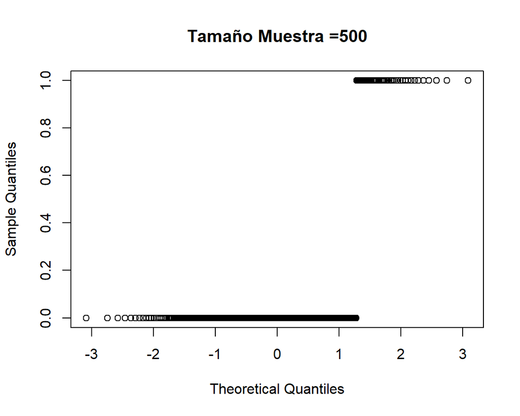

```r
for(tamanoMuestra in tamanosMuestra) {
  muestra <- sample(poblacion10PorcientoEnferma, tamanoMuestra, replace = FALSE)
  qqnorm(muestra, main=paste0("Tamaño Muestra =", tamanoMuestra))
}
```

**Lotes con 90% de plantas enfermas**

```r
poblacion90PorcientoEnferma <- sample(c(rep(1, 1000*0.9), rep(0, 1000*0.1)))
poblacion90PorcientoEnferma
```

[output not shown]

```r
numeroAleatorio2 <- runif(1, 100, 500);
numeroAleatorio2
```

```
[1] 351.8954
```

```r
muestraAleatoria2 <- sample(poblacion90PorcientoEnferma, numeroAleatorio2, replace = FALSE)
muestraAleatoria2
```

```
  [1] 1 1 1 1 1 1 1 1 1 1 1 1 1 1 1 1 1 1 1 1 1 1 1 0 1 1 1 1 1 0 1 1 1 1 1 1 1
 [38] 1 1 0 1 1 1 1 1 1 1 1 1 1 1 1 1 1 1 1 1 1 0 1 1 1 1 1 1 1 1 1 1 1 1 1 1 1
 [75] 1 1 1 1 1 0 1 1 1 1 1 1 1 1 1 1 1 1 1 1 0 1 1 1 1 1 1 1 1 1 1 1 1 0 1 1 1
[112] 1 1 1 1 1 1 1 1 1 1 0 1 1 0 1 1 1 1 1 1 1 0 1 1 1 1 1 1 1 1 1 1 1 1 1 1 0
[149] 0 1 1 1 1 1 1 1 1 1 0 1 1 1 1 1 1 1 1 1 1 1 1 1 1 1 1 1 0 1 1 1 1 1 1 1 1
[186] 1 1 1 1 1 1 1 1 1 1 1 1 1 1 1 1 0 1 1 1 1 1 1 1 1 1 1 1 1 1 1 1 1 1 1 1 1
[223] 1 1 0 1 1 1 1 1 1 1 0 1 1 0 1 1 1 0 1 1 1 0 1 1 1 1 1 1 1 1 1 1 1 1 1 1 1
[260] 1 1 1 1 1 1 1 1 1 1 1 1 1 1 1 1 1 0 1 1 1 1 1 1 1 0 1 1 0 1 1 1 1 0 1 1 1
[297] 0 1 1 1 1 1 1 1 1 1 1 1 0 1 1 1 1 1 1 1 0 1 1 1 1 1 1 1 1 0 1 1 1 1 1 1 0
[334] 1 1 1 0 1 1 1 1 1 1 1 1 1 1 1 1 0 1
```

```r
pEstimadorMuestraAleatoria2 <- sum(muestraAleatoria2 == 1) / length(muestraAleatoria2)
pEstimadorMuestraAleatoria2
```

```
[1] 0.9116809
```

```r
pEstimadorMuestraAleatoria2 <- sum(muestraAleatoria2 == 1) / length(muestraAleatoria2)
pEstimadorMuestraAleatoria2
```

```
[1] 0.9116809
```

```r
tamanosMuestra = c(5, 10, 15, 20, 30, 50, 60, 100, 200, 500)
tamanosMuestra
```

```
 [1]   5  10  15  20  30  50  60 100 200 500
```

```r
for(tamanoMuestra in tamanosMuestra) {
  cat("\n\nMuestra tamano: " , tamanoMuestra, '\n')
  muestraAleatoria3 <- sample(poblacion90PorcientoEnferma, tamanoMuestra, replace = FALSE)
  cat(muestraAleatoria3)
  pEstimadorMuestraAleatoria3 <- sum(muestraAleatoria3 == 1) / length(muestraAleatoria3)
  cat("\nEstimador de la proporción muestral: ", pEstimadorMuestraAleatoria3)
  print(shapiro.test(muestra))
}
```

```
Muestra tamano:  5
1 1 1 1 1
Estimador de la proporción muestral:  1
    Shapiro-Wilk normality test

data:  muestra
W = 0.34204, p-value < 2.2e-16



Muestra tamano:  10
0 1 0 1 1 1 1 1 1 1
Estimador de la proporción muestral:  0.8
    Shapiro-Wilk normality test

data:  muestra
W = 0.34204, p-value < 2.2e-16



Muestra tamano:  15
1 1 1 1 1 1 1 1 1 1 1 1 1 1 1
Estimador de la proporción muestral:  1
    Shapiro-Wilk normality test

data:  muestra
W = 0.34204, p-value < 2.2e-16



Muestra tamano:  20
1 1 1 1 1 1 1 1 1 1 1 1 1 1 1 0 1 1 1 1
Estimador de la proporción muestral:  0.95
    Shapiro-Wilk normality test

data:  muestra
W = 0.34204, p-value < 2.2e-16



```

[output cut: 42 more lines]

```
Estimador de la proporción muestral:  0.93
    Shapiro-Wilk normality test

data:  muestra
W = 0.34204, p-value < 2.2e-16



Muestra tamano:  500
1 1 1 0 1 1 1 1 0 1 1 0 1 1 1 1 1 1 1 1 1 1 1 1 1 1 1 1 1 1 1 1 0 0 1 1 1 1 0 1 1 1 1 1 1 1 1 1 1 1 1 1 1 0 1 0 1 1 1 1 1 1 1 1 1 1 1 0 1 1 1 1 1 1 1 1 1 1 1 1 1 1 1 0 1 1 1 1 1 1 1 0 1 1 1 0 1 1 1 0 1 1 1 1 1 1 1 1 1 1 1 1 1 1 1 0 1 1 0 1 1 1 1 1 0 1 1 1 1 1 1 0 0 0 0 1 1 1 1 1 1 1 0 1 1 1 1 1 0 1 …
Estimador de la proporción muestral:  0.898
    Shapiro-Wilk normality test

data:  muestra
W = 0.34204, p-value < 2.2e-16
```